# Proyecto No.2 Serie de Tiempo

# EJERCICIO No.1

## Libreria

```r
rm(list = ls())

library(dplyr)
library(forecast)
library(ggplot2)
library(lubridate)
library(tidyverse)
```

##No.1: Cree un arreglo con distribucion de probabilidad normal con media=0 y desviacion standar=5

```r
set.seed(123)
x <- rnorm(1500, mean=0, sd=5)
```

##No.2: Cree una suma acumulada de estos valores

```r
y = cumsum(x)
```

##No.3: Muestre una grafica de la serie temporal

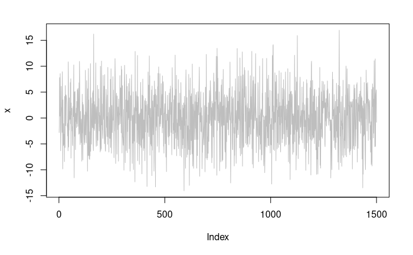

```r
plot(x, type = 'l', col='gray')
```

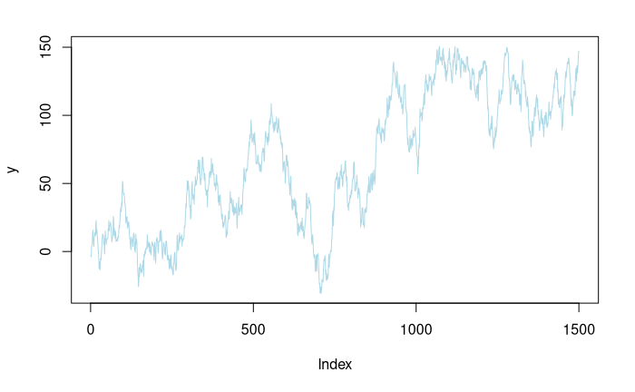

```r
plot(y, type = 'l', col='lightblue')
```

comentario: Las graficas de las variables creadas, x=representa arreglo con distribucion de probabilidad normal, y=suma acumulada de los valores de x. Se puede destacar la tendencia registrada en la variable y.

##No.4: Cree una serie de tiempo con la funcion ts()

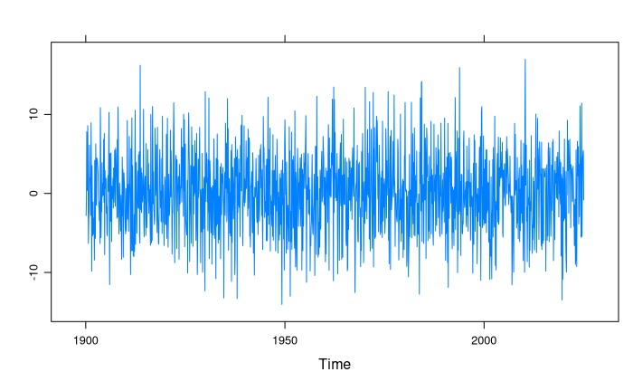

```r
x.ts <- ts(data=x, start=c(1900, 2), frequency = 12)
y.ts <- ts(data=y, start=c(1900, 2), frequency = 12)

lattice::xyplot.ts(x.ts)
```

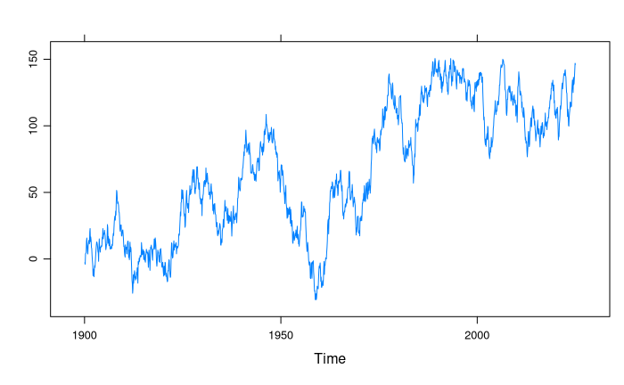

```r
lattice::xyplot.ts(y.ts)
```

## No.5: Verifique la descomposicion de la serie de tiempo, usando una frecuencia de 12

```r
data <- decompose(y.ts)
data
```

```
$x
              Jan          Feb          Mar          Apr          May          Jun          Jul          Aug          Sep          Oct          Nov          Dec
1900               -2.80237823  -3.95326568   3.84027589   4.19281785   4.83925652  13.41458146  15.71916249   9.39385631   5.95959206   3.73128220   9.85169119
1901  11.65076033  13.65461758  14.20803116  11.42882549  20.36339117  22.85264356  13.01955778  16.52633729  14.16238025   8.82326172   7.73338714   2.60336490
1902  -1.04109124  -4.16628758 -12.59975414  -8.41081891  -7.64395333 -13.33463801  -7.06556340  -4.93324230  -6.40859971  -1.93297141   2.45769603   6.56560144
1903  10.00880271  12.77839098  12.46883242  10.93901911   9.03666410   5.56312921   4.52354282  -1.80343894   9.04134088  15.08115088   9.46560796   7.45118378
1904   5.11790702   9.01773261   8.60088727   9.86747984   9.72474607   9.51039378  16.35340520  15.22455027  22.80690330  15.06313927  17.98620802  18.60547924
1905  19.68518709  21.58338450  19.07176723  17.40573032  12.31285340   6.95389727   8.47154047  10.71258937  10.97761050  15.58894784  25.83937127  23.38421544
1906  11.83837106  16.86706368  13.32105987   9.88101679  15.00887364  13.58500860   7.48142004   8.38793744   7.69348063   7.72230156   9.64870356   7.79540340
1907  11.01728614   9.91485334  11.57376315  17.05795822  19.23386567  17.60420775  23.34824584  28.31576512  31.05774992  32.25140859  29.11187821  35.91514045
1908  32.91384252  43.85050748  51.51356062  50.33505882  45.20295432  41.65092150  42.93534005  41.70188065  39.96416766  35.20607482  34.98093620  31.05641385
1909  22.71670417  20.81557156  25.41055461  22.53381980  25.57364141  17.48422787  17.20641804  19.80345406  21.30922087  21.83760184  18.63407180  14.38555007
1910   9.26490611   9.85313910   5.11576603   2.66297881   1.38251785  10.60182788   7.34207837   8.51901123   8.90881548   4.09953231   3.74299188  10.96574617
1911  13.22326643  13.42943104  11.31694688   1.05071077   6.70739684  -0.59580351   3.10393404  12.64945189   5.42998608   8.93890776   7.62792031  -0.23280048
1912  -7.80613875 -15.81381962 -18.46835223 -25.77713016 -22.33754629 -11.83700159 -18.27215397 -14.33345973 -10.48824853  -8.82723563 -13.86911867 -14.46638171
```

[output cut: 425 more lines]

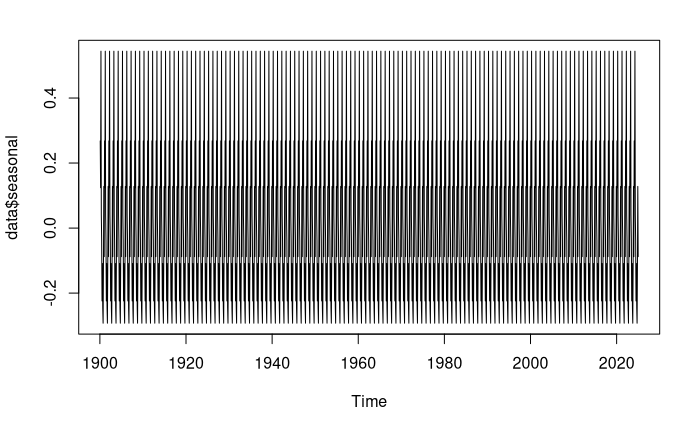

```r
plot(data$seasonal)
```

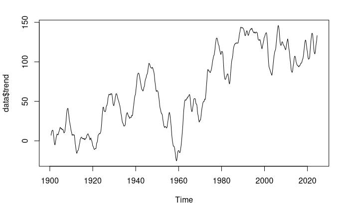

```r
plot(data$trend)
```

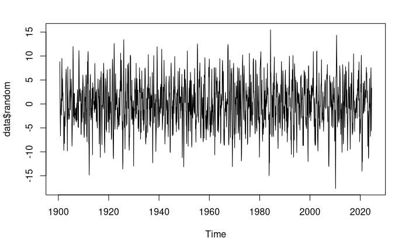

```r
plot(data$random)
```

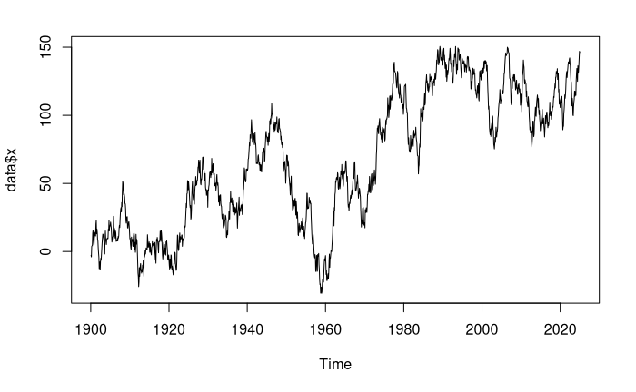

```r
plot(data$x)
```

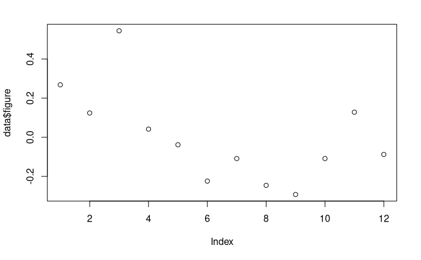

```r
plot(data$figure)
```

## No.6: Realice comentario sobre cada uno de los componentes de la serie temporal

Una serie de tiempo, es una secuencia de casos u observaciones en intervalos de tiempo que sigue una estructura regular. Este tipo de datos tiene a su vez componentes propios que actuan al mismo tiempo, estos son los que contribuyen a formar las caracteristicas de la serie de tiempo; entre los cuales podemos mencionar:

1. Tendencia: Muestra el patron que sigue la evolucion de los datos a traves del tiempo de analisis, este componente constituye la base del incremento o decremento de la serie de tiempo, se identifica con un movimiento suave de la serie a largo plazo. Ejm: la produccion de cierto producto en una empresa, tiene una tendencia que estara afectada por diversos factores.
2. Estacionalidad Representa la variacion de los datos en la serie debido a influencias estacionales. Estos efectos se pueden medir explicitamente o incluso se pueden eliminar de la serie de datos, a este proceso se le llama desestacionalizacion de la serie. Ejm: una empresa de venta de helados sabe que durante los meses de invierno las ventas de sus productos caeran debido al clima en dicha estacion.
3. Ciclicidad Hace referencia a las secuencias o patrones de crecimiento y decrecimiento en la linea de tendencia que duran mas de un año. Este componente es el conjunto de ciclos, de mas de un año de duracion que se producen por diversos factores.
4. La variacion irregular o aleatoriedad Se debe a factores de corto plazo, que no pueden preverse y que afectan a la serie; asimismo, explica la variabilidad irregular del comportamiento de la serie y es impredecible. Esta componente no responde a ningun patron de comportamiento, sino que es el resultado de factores fortuitos o aleatorios que inciden de forma aislada en una serie de tiempo.

## No.7: Determine si la serie es estacionaria o no (stationarity)

Una serie de tiempo es estrictamente estacionario si la distribucion no varia despues de un cambio arbitrario de tiempo. Se debe notar que la estacionariedad estricta implica que la media y la varianza son constantes en el tiempo y la autocovarianza solo depende del rezago. Por su parte, si una serie no estrictamente estacionaria pero la media y la varianza son constantes en el tiempo y la autocovarianza solo depende del rezago, la serie tendra estacionariedad de segundo orden.

#### Variable “X”

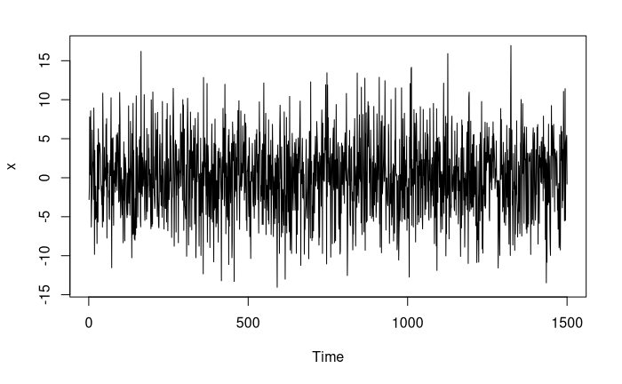

```r
plot.ts(x)
```

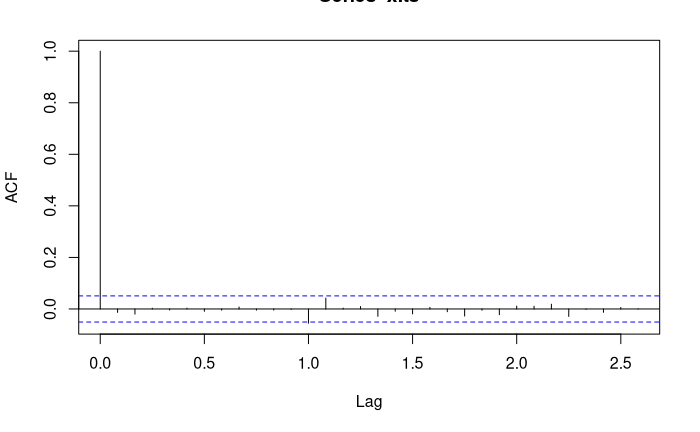

```r
acf(x.ts)
```

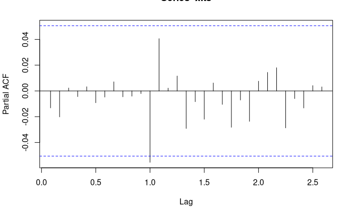

```r
pacf(x.ts)
```

#### Variable “Y”

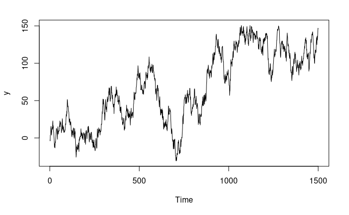

```r
plot.ts(y)
```

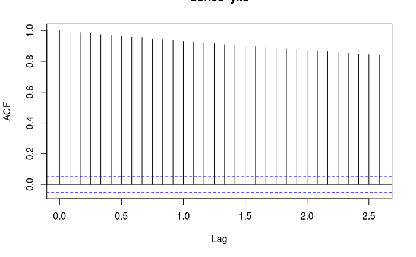

```r
acf(y.ts)
```

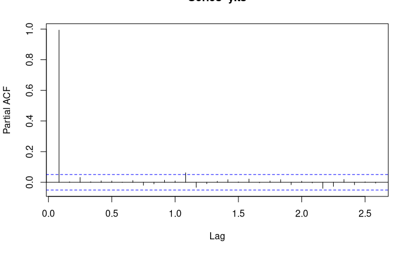

```r
pacf(y.ts)
```

Comentario:

Variable “Y”: muestra una tendencia, se puede decir que no es estacionaria. En relacion la estructura de la función de autocorrelación, tanto total como parcial, hace indicar que la serie sigue un ARMA(1,0), ya que vemos que para la función de autocorrelación a medida que aumentan los rezagos esta decrece de forma gradual, caso diferente para la función de autocorrelación parcial, que muestra un descenso repentino a partir del segundo rezago.

## No.8: De no ser estacionaria, investigue como es posible resolver este problema usando diferenciacion temporal

La estacionariedad se obtiene diferenciando la serie y aplicando logaritmos (Trasformacion Box-Cox). A partir de las correlaciones se va a poder tomar decisiones sobre cual es el tipo de modelo estadistico mas adecuado para dicha serie de tiempo.

```r
library(tseries)

ABC = diff(y.ts)
head(ABC)
```

```
            Mar        Apr        May        Jun        Jul        Aug
1900 -1.1508874  7.7935416  0.3525420  0.6464387  8.5753249  2.3045810
```

```r
#A123 <- log(y.ts)
#No se pudo realizar transfromacion logaritmica
```

#### Pruebas Estadisticas

```r
adf.test(ABC)
```

```
p-value smaller than printed p-value
```

```
    Augmented Dickey-Fuller Test

data:  ABC
Dickey-Fuller = -11.881, Lag order = 11, p-value = 0.01
alternative hypothesis: stationary
```

Comentario: como puede verse, rechazamos la hipótesis nula de que los datos transformados en el primer registro de diferencias tienen una raíz unitaria. Se puede decir que la serie temporal es estacionaria.

#### Prueba Estadistica

```r
kpss.test(ABC, null="Trend")
```

```
p-value greater than printed p-value
```

```
    KPSS Test for Trend Stationarity

data:  ABC
KPSS Trend = 0.024454, Truncation lag parameter = 7, p-value = 0.1
```

Comentario: Como puede verse, no rechazamos la hipótesis nula de que los datos son tendencia estacionarios.

## Pregunta No.9: Muestre una grafica sobre la serie temporal resultante

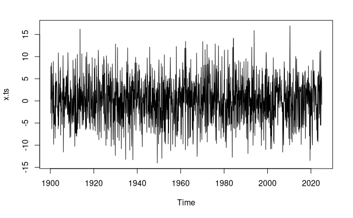

```r
plot(x.ts)
```

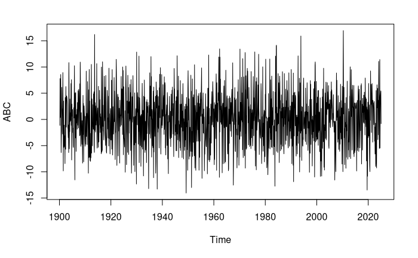

```r
plot(ABC)
```

```r
#acf(ABC)
#pacf(ABC)
```

# EJERCICIO No.2

## Cargar dataset

```r
dataset <- read.csv("dataOut.csv", sep=",")
dataset <- as.data.frame(dataset)

str(dataset)
```

```
'data.frame':   1344 obs. of  3 variables:
 $ timestamp  : chr  "2015-01-01" "2015-02-01" "2015-03-01" "2015-04-01" ...
 $ id_producto: chr  "605836c043ec8e96037561ee446c3757" "605836c043ec8e96037561ee446c3757" "605836c043ec8e96037561ee446c3757" "605836c043ec8e96037561ee446c3757" ...
 $ produccion : num  2766 2767 2767 2767 2770 ...
```

## Crear Variable ‘timestamp’ como una serie de tiempo

```r
dataset$time <- ts(dataset$timestamp, frequency = 12)
```

## Crear una variable para Productos con un id manejable para el analisis de los datos

```r
ABC <- dataset %>%
  group_by(id_producto) %>%
  summarise(produccion = sum(produccion))
#ABC

dataset$producto <- as.factor(substr(dataset$id_producto, start = 1, stop = 5))
levels(dataset$producto) <- paste0("producto", 1:16)
```

## Visualizacion Produccion por producto

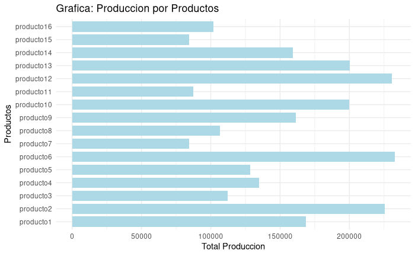

```r
producto <- table(dataset %>% select(producto, produccion))
ggplot(data= dataset %>% group_by(producto) %>%
         summarise(produccion = sum(produccion)), aes(x=producto, y=produccion)) +
  geom_bar(stat = "identity", width = 0.8, fill="lightblue") +
  coord_flip() +
  ggtitle("Grafica: Produccion por Productos") +
  xlab("Productos") +
  ylab("Total Produccion") +
  theme_minimal()
```

## dataset por productos individuales

```r
Prod01 <- dataset %>% filter(producto == 'producto1') %>% select(time, produccion, producto)
Prod02 <- dataset %>% filter(producto == 'producto2') %>% select(time, produccion, producto)
Prod03 <- dataset %>% filter(producto == 'producto3') %>% select(time, produccion, producto)
Prod04 <- dataset %>% filter(producto == 'producto4') %>% select(time, produccion, producto)
Prod05 <- dataset %>% filter(producto == 'producto5') %>% select(time, produccion, producto)
Prod06 <- dataset %>% filter(producto == 'producto6') %>% select(time, produccion, producto)
Prod07 <- dataset %>% filter(producto == 'producto7') %>% select(time, produccion, producto)
Prod08 <- dataset %>% filter(producto == 'producto8') %>% select(time, produccion, producto)
Prod09 <- dataset %>% filter(producto == 'producto9') %>% select(time, produccion, producto)
Prod10 <- dataset %>% filter(producto == 'producto10') %>% select(time, produccion, producto)
Prod11 <- dataset %>% filter(producto == 'producto11') %>% select(time, produccion, producto)
Prod12 <- dataset %>% filter(producto == 'producto12') %>% select(time, produccion, producto)
Prod13 <- dataset %>% filter(producto == 'producto13') %>% select(time, produccion, producto)
Prod14 <- dataset %>% filter(producto == 'producto14') %>% select(time, produccion, producto)
Prod15 <- dataset %>% filter(producto == 'producto15') %>% select(time, produccion, producto)
Prod16 <- dataset %>% filter(producto == 'producto16') %>% select(time, produccion, producto)
```

#### Producto No.1

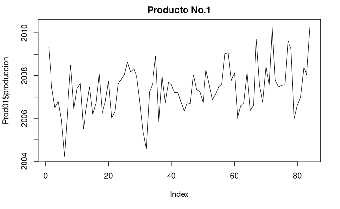

```r
# Declarar que se trabaja con serie de tiempo
# ====================================================================
Prod01.ts =  ts(Prod01$produccion, start = c(2015,1), frequency = 12)

# Visualizacion de la estructura de datos
# ====================================================================
plot(Prod01$produccion, type = "l", main = "Producto No.1")
```

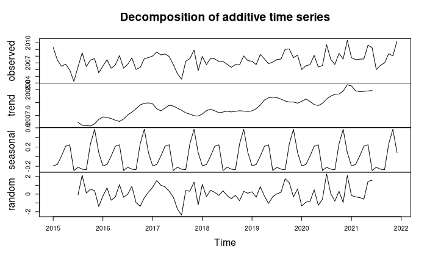

```r
plot(decompose(Prod01.ts))
```

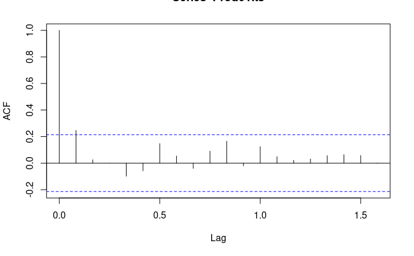

```r
acf(Prod01.ts)
```

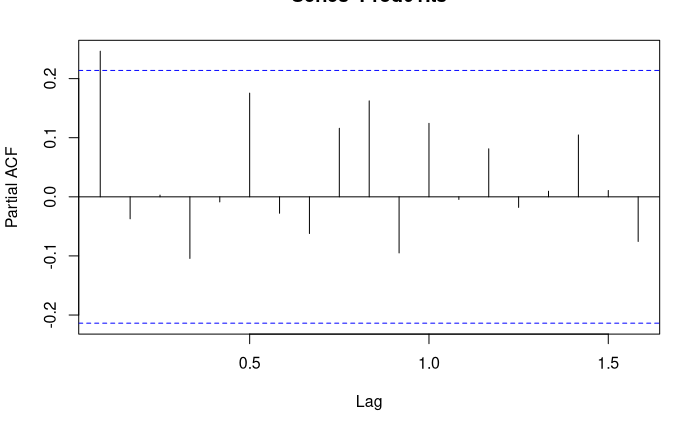

```r
pacf(Prod01.ts)
```

```r
# Estimar Modelo
# ===================================================================
Prod01.arima = auto.arima(x=Prod01.ts)
Prod01.arima
```

```
Series:
ARIMA(0,1,2)

Coefficients:
          ma1      ma2
      -0.6951  -0.2341
s.e.   0.1168   0.1137

sigma^2 estimated as 1.268:  log likelihood=-125.87
AIC=257.75   AICc=258.05   BIC=265
```

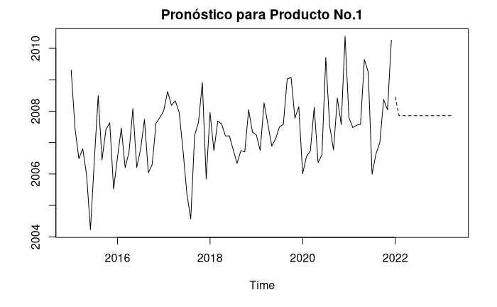

```r
Prod01.predict <- predict(Prod01.arima, n.ahead = 16)
Prod01.rev <- ts((Prod01.predict$pred), start=c(2022,1), freq=12)
ts.plot(cbind(Prod01.ts, Prod01.rev), lty=1:2, main="Pronóstico para Producto No.1")
```

#### Producto No.2

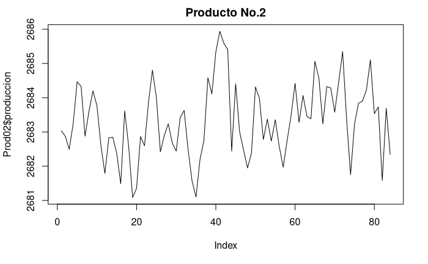

```r
# Declarar que se trabaja con serie de tiempo
# ====================================================================
Prod02.ts =  ts(Prod02$produccion, start= c(2015,1), frequency = 12)

# Visualizacion de la estructura de datos
# ====================================================================
plot(Prod02$produccion, type="l", main = "Producto No.2")
```

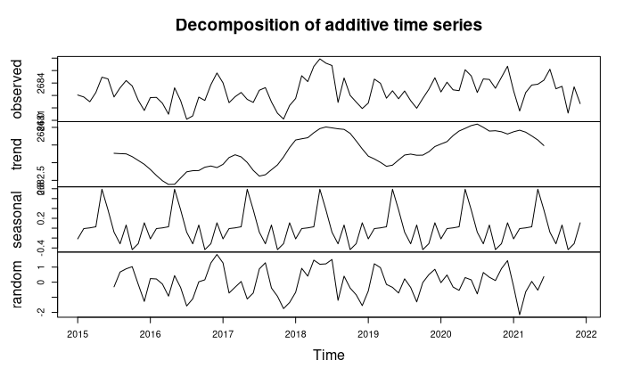

```r
plot(decompose(Prod02.ts))
```

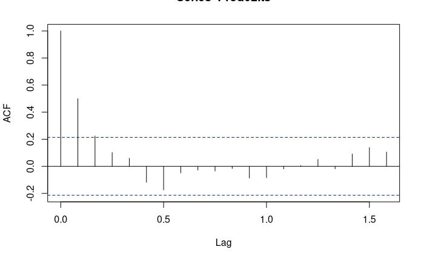

```r
acf(Prod02.ts)
```

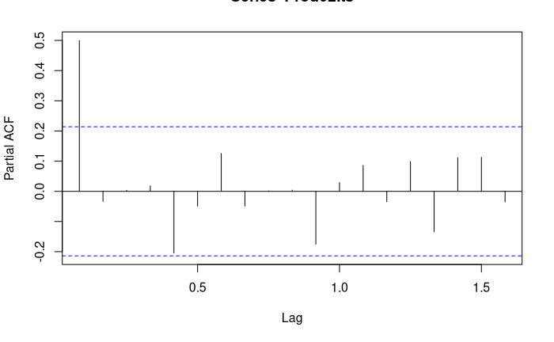

```r
pacf(Prod02.ts)
```

```r
# Estimar Modelo
# ===================================================================
Prod02.arima = auto.arima(x=Prod02.ts)
Prod02.arima
```

```
Series:
ARIMA(1,0,0) with non-zero mean

Coefficients:
         ar1       mean
      0.4992  2683.3093
s.e.  0.0939     0.1992

sigma^2 estimated as 0.8764:  log likelihood=-112.78
AIC=231.56   AICc=231.86   BIC=238.85
```

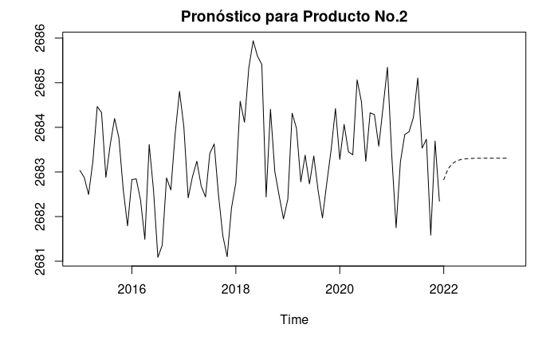

```r
Prod02.predict <- predict(Prod02.arima, n.ahead = 16)
Prod02.rev <- ts((Prod02.predict$pred), start=c(2022,1), freq=12)
ts.plot(cbind(Prod02.ts, Prod02.rev), lty=1:2,main="Pronóstico para Producto No.2")
```